# Analyzing Ford GoBike/Bay Wheels Data

### By Ayush

- Introduction
- Part I - Gathering Data
- Part II - Assessing Data
- Part III - Cleaning Data
- Part IV - Univariate Exploration
- Part V - Bivariate Exploration
- Part VI - Multivariate Exploration

## Introduction

On June 28 2017,The Ford GoBike was officially re-launched in a partnership with Ford Motor Company. It is a regional public bicycle sharing system in the San Francisco Bay Area, California. After Motivate's acquisition by **Lyft**, the system was subsequently renamed to **Bay Wheels** in June 2019. The system is expected to expand to 7,000 bicycles around 540 stations in San Francisco, Oakland, Berkeley, Emeryville, and San Jose.  
Bay wheels, like other bike share systems, consists of a fleet of specially designed, sturdy and durable bikes that are locked into a network of docking stations throughout the city. The bikes can be unlocked from one station and returned to any other station in the system, making them ideal for one-way trips. The bikes are available for use 24 hours/day, 7 days/week, 365 days/year and riders have access to all bikes in the network when they become a member or purchase a pass.

### Preliminary Wrangling

This document explores the Bay Wheel's trip data for public containing approximately `905007` bike rides from first quarter of FY2020

## Part I - Gathering Data

```python
# importing libraries
import numpy as np
import pandas as pd
import time
import datetime
import math
import matplotlib.pyplot as plt
import seaborn as sns
import os
import glob

%matplotlib inline
```

```python
#path to the folder where all files has been stored
path = r'/home/ayush/Desktop/Dand_cdf/data/'

files = glob.glob(os.path.join(path, "*.csv"))

df = pd.concat((pd.read_csv(f) for f in files), ignore_index = True)

df.to_csv('Bay_Wheels_data.csv', index = False)
```

## Part II - Assessing Data

```python
#check first 5 rows of data
df.head()
```

|  | duration_sec | start_time | end_time | start_station_id | start_station_name | start_station_latitude | start_station_longitude | end_station_id | end_station_name | end_station_latitude | end_station_longitude | bike_id | user_type | rental_access_method |
| --- | --- | --- | --- | --- | --- | --- | --- | --- | --- | --- | --- | --- | --- | --- |
| 0 | 83118 | 2020-01-31 15:23:47.7330 | 2020-02-01 14:29:06.2630 | 400.0 | Buchanan St at North Point St | 37.804272 | -122.433537 | 400.0 | Buchanan St at North Point St | 37.804272 | -122.433537 | 13052 | Customer | NaN |
| 1 | 68239 | 2020-01-31 15:40:31.6160 | 2020-02-01 10:37:51.0000 | 99.0 | Folsom St at 15th St | 37.767037 | -122.415443 | 99.0 | Folsom St at 15th St | 37.767037 | -122.415443 | 12235 | Subscriber | NaN |
| 2 | 55407 | 2020-01-31 17:48:16.6350 | 2020-02-01 09:11:44.3170 | 197.0 | El Embarcadero at Grand Ave | 37.808848 | -122.249680 | 197.0 | El Embarcadero at Grand Ave | 37.808848 | -122.249680 | 12822 | Customer | NaN |
| 3 | 54929 | 2020-01-31 17:53:03.4130 | 2020-02-01 09:08:32.6340 | 197.0 | El Embarcadero at Grand Ave | 37.808848 | -122.249680 | 197.0 | El Embarcadero at Grand Ave | 37.808848 | -122.249680 | 11705 | Customer | NaN |
| 4 | 55700 | 2020-01-31 17:12:33.4600 | 2020-02-01 08:40:53.6460 | 12.0 | Pier 1/2 at The Embarcadero | 37.796389 | -122.394586 | 371.0 | Lombard St at Columbus Ave | 37.802746 | -122.413579 | 3673 | Customer | NaN |

```python
#check 5 random rows of data
df.sample(5)
```

|  | duration_sec | start_time | end_time | start_station_id | start_station_name | start_station_latitude | start_station_longitude | end_station_id | end_station_name | end_station_latitude | end_station_longitude | bike_id | user_type | rental_access_method |
| --- | --- | --- | --- | --- | --- | --- | --- | --- | --- | --- | --- | --- | --- | --- |
| 261551 | 974 | 2020-01-31 15:51:15 | 2020-01-31 16:07:29 | NaN | NaN | 37.790084 | -122.389444 | NaN | NaN | 37.771000 | -122.410716 | 590631 | Subscriber | clipper |
| 442660 | 997 | 2020-02-11 19:53:36 | 2020-02-11 20:10:13 | NaN | NaN | 37.746291 | -122.423135 | NaN | NaN | 37.768259 | -122.392660 | 772389 | Subscriber | app |
| 354106 | 2208 | 2020-02-16 09:48:44.7210 | 2020-02-16 10:25:33.3570 | 313.0 | Almaden Blvd at San Fernando St | 37.331415 | -121.893200 | 313.0 | Almaden Blvd at San Fernando St | 37.331415 | -121.893200 | 10913 | Customer | NaN |
| 18222 | 793 | 2020-01-27 16:26:03.8210 | 2020-01-27 16:39:17.4770 | 460.0 | Terry Francois Blvd at Warriors Way | 37.769095 | -122.386333 | 12.0 | Pier 1/2 at The Embarcadero | 37.796389 | -122.394586 | 12353 | Customer | NaN |
| 693321 | 465 | 2020-02-28 14:10:44 | 2020-02-28 14:18:29 | NaN | NaN | 37.795448 | -122.398555 | NaN | NaN | 37.804403 | -122.410032 | 105633 | Subscriber | app |

```python
#Look for number of rows and columns
df.shape
```

```
(905007, 14)
```

```python
#Discribes the quantitative column
df.describe()
```

|  | duration_sec | start_station_id | start_station_latitude | start_station_longitude | end_station_id | end_station_latitude | end_station_longitude | bike_id |
| --- | --- | --- | --- | --- | --- | --- | --- | --- |
| count | 905007.000000 | 418705.000000 | 905007.000000 | 905007.000000 | 419225.000000 | 905007.000000 | 905007.000000 | 905007.000000 |
| mean | 806.783430 | 175.490438 | 37.747956 | -122.356863 | 168.499295 | 37.747504 | -122.354743 | 345257.165427 |
| std | 1651.803494 | 146.361852 | 0.229245 | 0.646076 | 145.618964 | 0.270214 | 0.795225 | 305503.123238 |
| min | 60.000000 | 3.000000 | 0.000000 | -122.514230 | 3.000000 | 0.000000 | -122.575763 | 12.000000 |
| 25% | 370.000000 | 56.000000 | 37.765281 | -122.420664 | 44.000000 | 37.765464 | -122.419957 | 12114.000000 |
| 50% | 595.000000 | 123.000000 | 37.776972 | -122.404635 | 116.000000 | 37.777062 | -122.403681 | 326439.000000 |
| 75% | 932.000000 | 275.000000 | 37.789914 | -122.392741 | 265.000000 | 37.790229 | -122.392741 | 557460.000000 |
| max | 811077.000000 | 521.000000 | 37.880222 | 0.000000 | 521.000000 | 37.995942 | 0.000000 | 999960.000000 |

```python
#check for null values
df.isnull().sum()
```

```
duration_sec                    0
start_time                      0
end_time                        0
start_station_id           486302
start_station_name         485069
start_station_latitude          0
start_station_longitude         0
end_station_id             485782
end_station_name           484508
end_station_latitude            0
end_station_longitude           0
bike_id                         0
user_type                       0
rental_access_method       287149
dtype: int64
```

```python
#check for data types
df.info()
```

```
<class 'pandas.core.frame.DataFrame'>
RangeIndex: 905007 entries, 0 to 905006
Data columns (total 14 columns):
 #   Column                   Non-Null Count   Dtype
---  ------                   --------------   -----
 0   duration_sec             905007 non-null  int64
 1   start_time               905007 non-null  object
 2   end_time                 905007 non-null  object
 3   start_station_id         418705 non-null  float64
 4   start_station_name       419938 non-null  object
 5   start_station_latitude   905007 non-null  float64
 6   start_station_longitude  905007 non-null  float64
 7   end_station_id           419225 non-null  float64
 8   end_station_name         420499 non-null  object
 9   end_station_latitude     905007 non-null  float64
 10  end_station_longitude    905007 non-null  float64
 11  bike_id                  905007 non-null  int64
 12  user_type                905007 non-null  object
 13  rental_access_method     617858 non-null  object
dtypes: float64(6), int64(2), object(6)
memory usage: 96.7+ MB
```

```python
#check if duplicates exists
df.duplicated().sum()
```

```
7512
```

### Quality Issues:

- Change Data type of `start_time` and `end_time` to datetime type.
- Data is missing in some of the columns :-

  ```
    start_station_id
    start_station_name
    end_station_name
    end_station_id
    rental_access_method
  ```

- Remove the duplicate values.
- We can calculate the distance traveled by the user.
- We can further enhance the dataset with more details about the time (e.g.- month, day, hour, weekday)
- We can calculate the duration of travel(or even speed)

## Part III - Cleaning Data

```python
# Create copies of original DataFrames
df_clean = df.copy()
```

**Define**  
Set data types for fields mentioned in the Quality Issues

**Code**

```python
df_clean.start_time = pd.to_datetime(df_clean.start_time)
df_clean.end_time = pd.to_datetime(df_clean.end_time)
```

**Test**

```python
df_clean.info()
```

```
<class 'pandas.core.frame.DataFrame'>
RangeIndex: 905007 entries, 0 to 905006
Data columns (total 14 columns):
 #   Column                   Non-Null Count   Dtype
---  ------                   --------------   -----
 0   duration_sec             905007 non-null  int64
 1   start_time               905007 non-null  datetime64[ns]
 2   end_time                 905007 non-null  datetime64[ns]
 3   start_station_id         418705 non-null  float64
 4   start_station_name       419938 non-null  object
 5   start_station_latitude   905007 non-null  float64
 6   start_station_longitude  905007 non-null  float64
 7   end_station_id           419225 non-null  float64
 8   end_station_name         420499 non-null  object
 9   end_station_latitude     905007 non-null  float64
 10  end_station_longitude    905007 non-null  float64
 11  bike_id                  905007 non-null  int64
 12  user_type                905007 non-null  object
 13  rental_access_method     617858 non-null  object
dtypes: datetime64[ns](2), float64(6), int64(2), object(4)
memory usage: 96.7+ MB
```

**Define**  
Remove the missing value rows for fields mentioned in the Quality Issues

**Code**

```python
# Remove rows that does not have start station id
df_clean = df_clean[df_clean['start_station_id'].isnull() == False]
```

```python
## Remove rows that does not have end station id
df_clean = df_clean[df_clean['end_station_id'].isnull() == False]
```

**Test**

```python
df_clean.info()
```

```
<class 'pandas.core.frame.DataFrame'>
Int64Index: 345449 entries, 0 to 902937
Data columns (total 14 columns):
 #   Column                   Non-Null Count   Dtype
---  ------                   --------------   -----
 0   duration_sec             345449 non-null  int64
 1   start_time               345449 non-null  datetime64[ns]
 2   end_time                 345449 non-null  datetime64[ns]
 3   start_station_id         345449 non-null  float64
 4   start_station_name       345449 non-null  object
 5   start_station_latitude   345449 non-null  float64
 6   start_station_longitude  345449 non-null  float64
 7   end_station_id           345449 non-null  float64
 8   end_station_name         345449 non-null  object
 9   end_station_latitude     345449 non-null  float64
 10  end_station_longitude    345449 non-null  float64
 11  bike_id                  345449 non-null  int64
 12  user_type                345449 non-null  object
 13  rental_access_method     58300 non-null   object
dtypes: datetime64[ns](2), float64(6), int64(2), object(4)
memory usage: 39.5+ MB
```

**Define**  
Droping some columns mentioned in the Quality Issues

**Code**

```python
df_clean=df_clean.drop(['rental_access_method'],axis=1)
```

```python
df_clean.drop_duplicates(keep=False,inplace=True)
```

**Test**

```python
df_clean.info()
```

```
<class 'pandas.core.frame.DataFrame'>
Int64Index: 344701 entries, 0 to 902937
Data columns (total 13 columns):
 #   Column                   Non-Null Count   Dtype
---  ------                   --------------   -----
 0   duration_sec             344701 non-null  int64
 1   start_time               344701 non-null  datetime64[ns]
 2   end_time                 344701 non-null  datetime64[ns]
 3   start_station_id         344701 non-null  float64
 4   start_station_name       344701 non-null  object
 5   start_station_latitude   344701 non-null  float64
 6   start_station_longitude  344701 non-null  float64
 7   end_station_id           344701 non-null  float64
 8   end_station_name         344701 non-null  object
 9   end_station_latitude     344701 non-null  float64
 10  end_station_longitude    344701 non-null  float64
 11  bike_id                  344701 non-null  int64
 12  user_type                344701 non-null  object
dtypes: datetime64[ns](2), float64(6), int64(2), object(3)
memory usage: 36.8+ MB
```

```python
#check for null values
df_clean.isnull().sum()
```

```
duration_sec               0
start_time                 0
end_time                   0
start_station_id           0
start_station_name         0
start_station_latitude     0
start_station_longitude    0
end_station_id             0
end_station_name           0
end_station_latitude       0
end_station_longitude      0
bike_id                    0
user_type                  0
dtype: int64
```

```python
#check for duplicate values
df_clean.duplicated().sum()
```

```
0
```

```python
#Number of rows and columns in df_clean
df_clean.shape
```

```
(344701, 13)
```

### Define:

Extract and Create new columns st_month_name, st_month, st_time_weekday, start_time_Day, start_time_hour

### Code:

```python
# extract month name from start_time
df_clean['st_month_name']=df_clean['start_time'].dt.strftime('%B')
```

```python
# extract month number from start_time
df_clean['start_time_month']=df_clean['start_time'].dt.month.astype(int)
```

```python
# extract weekdays from start_time
df_clean['start_time_weekday']=df_clean['start_time'].dt.strftime('%a')
```

```python
# extract day from start_time
df_clean['start_time_day']=df_clean['start_time'].dt.day.astype(int)
```

```python
# extract hour from start_time
df_clean['start_time_hour']=df_clean['start_time'].dt.hour
```

```python
#renaming to shorten the column names
df_clean.rename(columns={'start_time_month':'st_month',
                          'start_time_weekday':'st_weekday',
                          'start_time_day':'st_day',
                          'start_time_hour':'st_hour'},
                 inplace=True)
```

### Test:

```python
df_clean.info()
```

```
<class 'pandas.core.frame.DataFrame'>
Int64Index: 344701 entries, 0 to 902937
Data columns (total 18 columns):
 #   Column                   Non-Null Count   Dtype
---  ------                   --------------   -----
 0   duration_sec             344701 non-null  int64
 1   start_time               344701 non-null  datetime64[ns]
 2   end_time                 344701 non-null  datetime64[ns]
 3   start_station_id         344701 non-null  float64
 4   start_station_name       344701 non-null  object
 5   start_station_latitude   344701 non-null  float64
 6   start_station_longitude  344701 non-null  float64
 7   end_station_id           344701 non-null  float64
 8   end_station_name         344701 non-null  object
 9   end_station_latitude     344701 non-null  float64
 10  end_station_longitude    344701 non-null  float64
 11  bike_id                  344701 non-null  int64
 12  user_type                344701 non-null  object
 13  st_month_name            344701 non-null  object
 14  st_month                 344701 non-null  int64
 15  st_weekday               344701 non-null  object
 16  st_day                   344701 non-null  int64
 17  st_hour                  344701 non-null  int64
dtypes: datetime64[ns](2), float64(6), int64(5), object(5)
memory usage: 50.0+ MB
```

**Lastly,**

```python
#Saves Cleaned data to sudh_data
df_clean.to_csv('sudh_data.csv', index = False)
```

### What is the structure of your dataset?

The original combined data contains approximately 9,05,007 individual trip records with 14 variables collected.

### What is the main feature of interest in the dataset?

The most interesting thing to explore is the bike trips, duration and rental usage trends, along with how these relate to the riders i.e. their user type etc, to get a sense of how and what people are using the bike sharing service for. Sample questions to answer: When are most trips taken in terms of time of day, day of the week, or month of the year? How long does the average trip take? Does the above depend on if a user is a subscriber or customer?

## Part IV - Univariate Exploration

A series of plots to explore the Bikes usage over hour-of-day, day-of-week and month.

### Monthly Bike Usage

```python
base_color=sns.color_palette()[0]
```

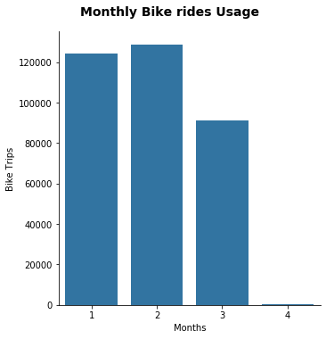

```python
g = sns.catplot(data=df_clean, x='st_month', kind='count', color=base_color)
g.set_axis_labels("Months", "Bike Trips")
g.fig.suptitle('Monthly Bike rides Usage', y=1.05, fontsize=14, fontweight='semibold');
```

Monthly comprision shows that there was slight increase in number of rides in month of febuary Before rides began to drop in march and finally there was no rides maybe due to recent covid-19 pandamic outbreak.

### Weekly Bike Usage

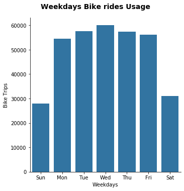

```python
weekday = ['Sun','Mon', 'Tue', 'Wed', 'Thu', 'Fri', 'Sat']
g = sns.catplot(data=df_clean, x='st_weekday', kind='count',color=base_color, order = weekday)
g.set_axis_labels("Weekdays", "Bike Trips")
g.fig.suptitle('Weekdays Bike rides Usage', y=1.05, fontsize=14, fontweight='semibold');
```

Comprision of weekdays usage of bikes shows us that there is more demand of bikes on full working days(mon-fri) however on weekends the demand of bikes becomes almost half.

### Hourly Bike Usage

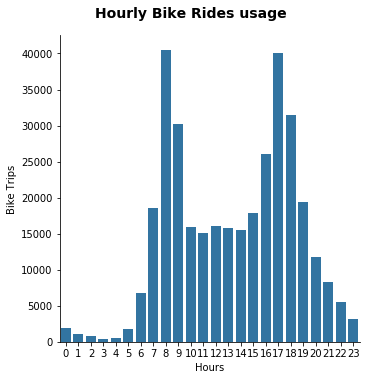

```python
g = sns.catplot(data=df_clean, x='st_hour', kind='count', color = base_color)
g.set_axis_labels("Hours", "Bike Trips")
g.fig.suptitle('Hourly Bike Rides usage', y=1.05, fontsize=14, fontweight='semibold');
```

Hourly comprision shows that their is peak demand for bikes two times a day . That is between 7-9 hours and 16-18 hours. Data also points that there is minimal demand during 0-5 hours.

### Discuss the distribution(s) of your variable(s) of interest. Were there any unusual points? Did you need to perform any transformations?

The number of trips peaked around 7-9am and 16-18pm during a day, there were more trips on work days (Mon-Fri) compared to weekends. There were more casual riders as compared to subscribers.

## Part V - Bi-Variate Exploration:

How does the trip duration distribution vary between customers and subscribers?

### Number of bike rides vs user_type

```python
# calculate split% for the user_type
customer = df_clean.query('user_type == "Customer"')['bike_id'].count()
subscriber = df_clean.query('user_type == "Subscriber"')['bike_id'].count()

customer_prop = customer / df_clean['bike_id'].count()
subscriber_prop = subscriber / df_clean['bike_id'].count()
```

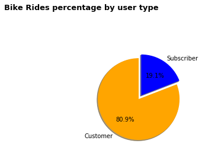

```python
plt.subplot(1, 2, 2)

labels = ['Customer', 'Subscriber']
sizes = [customer_prop, subscriber_prop]
colors = ['orange', 'blue']
explode = (0, 0.11)

plt.pie(sizes, explode=explode, labels=labels, colors = colors,
        autopct='%1.1f%%', shadow=True, startangle=90)
plt.axis('equal')

plt.suptitle('Bike Rides percentage by user type', y=1.05, fontsize=13, fontweight='semibold');
```

Of the all users only 19.1% are subscribers and rest 80.9% are customer's.Which isn't most promising condition.

### Monthly User Type Trendzzz

```python
def transform_axis_fmt(tick_val, pos):
    if tick_val >= 1000:
        val = int(tick_val/1000)
        return '{:d}K'.format(val)
    elif tick_val >= 1000000:
        val = int(tick_val/1000000)
        return '{:d}M'.format(val)
    else:
        return int(tick_val)
```

```python
count_usertype = df_clean.groupby(["st_month", "user_type"]).size().reset_index()
```

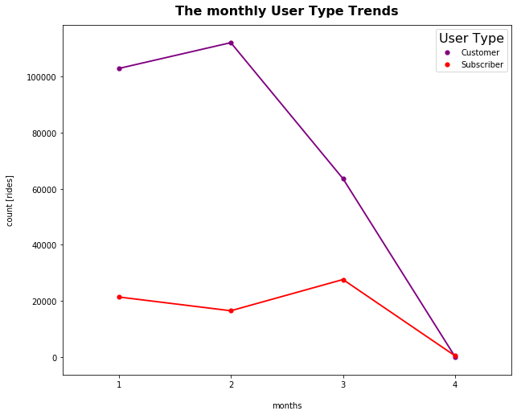

```python
plt.figure(figsize=(10,8))
colors = {'Subscriber':'red', 'Customer':'purple'}
ax = sns.pointplot(x='st_month', y=0, hue='user_type', palette=colors, scale=.7, data=count_usertype)
plt.title('The monthly User Type Trends', fontsize=16, y=1.015,fontweight='semibold')
plt.xlabel('months', labelpad=16)
plt.ylabel('count [rides]', labelpad=16)
leg = ax.legend()
leg.set_title('User Type',prop={'size':16});
```

Number of subscriber's have slightly increased over the months. Number of customers have increased slightly intialy before decreasing by huge margin. April month graph shows closure of services.

### Weekly Usage Trends Per User Types

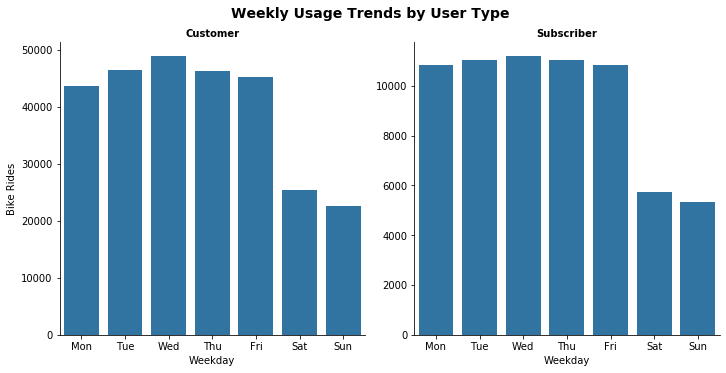

```python
weekday = ['Mon', 'Tue', 'Wed', 'Thu', 'Fri', 'Sat', 'Sun']
g = sns.catplot(data=df_clean, x='st_weekday', col="user_type", kind='count', sharey = False,
            color = base_color , order = weekday)
g.set_axis_labels("Weekday", "Bike Rides")
g.set_titles("{col_name}",fontsize=14, fontweight='bold')
g.fig.suptitle('Weekly Usage Trends by User Type', y=1.03, fontsize=14, fontweight='semibold');
```

Here both the plot shows identical trend.There is huge demand of bikes on weekdays for both customer and subscriber.Where as there is almost half the demand on weekends for both customers and subscribers.

### Hourly usage trends by User type:

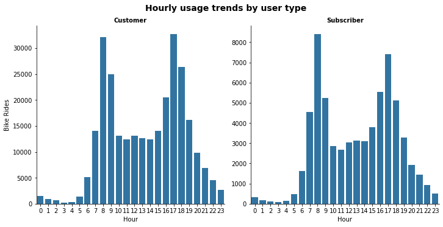

```python
g = sns.catplot(data=df_clean, x='st_hour', col="user_type", kind='count', sharey = False,
            color = base_color)
g.set_axis_labels("Hour", "Bike Rides")
g.set_titles("{col_name}",fontsize=14, fontweight='bold')
g.fig.suptitle('Hourly usage trends by user type', y=1.03, fontsize=14, fontweight='semibold');
```

Hourly trends of two data show identical trends.There is two peak points a day.One between 7-9 hours while other at 16-18 hours.

### Average Trip Duration Per user_type

```python
# Compute minutes for trip duration
df_clean['duration_min'] = df_clean['duration_sec']/60
```

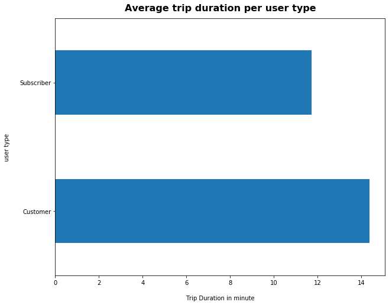

```python
ax = df_clean.groupby('user_type')['duration_min'].mean().plot(kind='barh', color=base_color, figsize=(10,8))
ax.set_title('Average trip duration per user type', fontsize=16, y=1.015,fontweight='semibold')
ax.set_ylabel('user type', labelpad=16)
ax.set_xlabel('Trip Duration in minute', labelpad=16);
```

Average trip duration per user_type plot shows that the average trip duration is more for customer than subscriber.

### Trip Duration Over The Months

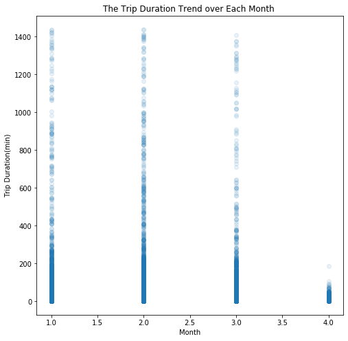

```python
# Trip duration over changes over each month.
plt.figure(figsize = [8,8]) # make the whole figure bigger
plt.scatter(data = df_clean , x = 'st_month' , y = 'duration_min' , alpha = 0.1 )
plt.title('The Trip Duration Trend over Each Month ')
plt.xlabel('Month')
plt.ylabel('Trip Duration(min)');
```

Trip duration trending shows the trip duration minute in each month.

### Average Bike Trip distance of subscribers vs customers:

```python
#Calculate distance
def distance(origin, destination):
    lat1, lon1 = origin
    lat2, lon2 = destination
    radius = 6371  # km

    dlat = math.radians(lat2 - lat1)
    dlon = math.radians(lon2 - lon1)
    a = (math.sin(dlat / 2) * math.sin(dlat / 2) +
         math.cos(math.radians(lat1)) * math.cos(math.radians(lat2)) *
         math.sin(dlon / 2) * math.sin(dlon / 2))
    c = 2 * math.atan2(math.sqrt(a), math.sqrt(1 - a))
    d = radius * c

    return d
```

```python
df_clean['distance_kms'] = df_clean.apply(lambda x: distance((x['start_station_latitude'], x['start_station_longitude']), (x['end_station_latitude'], x['end_station_longitude'])), axis=1)
```

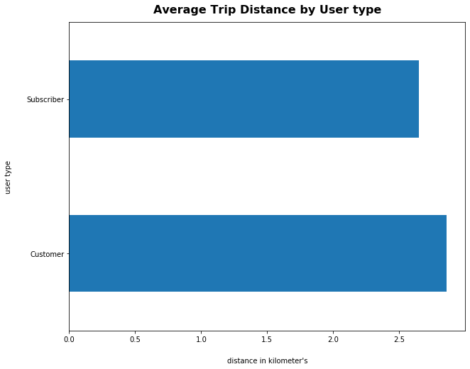

```python
ax = df_clean.groupby('user_type')['distance_kms'].mean().plot(kind='barh', color=base_color, figsize=(10,8))
ax.set_title('Average Trip Distance by User type', fontsize=16, y=1.015,fontweight='semibold')
ax.set_ylabel('user type', labelpad=20)
ax.set_xlabel("distance in kilometer's", labelpad=20);
```

```python
df_clean.info()
```

```
<class 'pandas.core.frame.DataFrame'>
Int64Index: 344701 entries, 0 to 902937
Data columns (total 20 columns):
 #   Column                   Non-Null Count   Dtype
---  ------                   --------------   -----
 0   duration_sec             344701 non-null  int64
 1   start_time               344701 non-null  datetime64[ns]
 2   end_time                 344701 non-null  datetime64[ns]
 3   start_station_id         344701 non-null  float64
 4   start_station_name       344701 non-null  object
 5   start_station_latitude   344701 non-null  float64
 6   start_station_longitude  344701 non-null  float64
 7   end_station_id           344701 non-null  float64
 8   end_station_name         344701 non-null  object
 9   end_station_latitude     344701 non-null  float64
 10  end_station_longitude    344701 non-null  float64
 11  bike_id                  344701 non-null  int64
 12  user_type                344701 non-null  object
 13  st_month_name            344701 non-null  object
 14  st_month                 344701 non-null  int64
 15  st_weekday               344701 non-null  object
 16  st_day                   344701 non-null  int64
 17  st_hour                  344701 non-null  int64
 18  duration_min             344701 non-null  float64
 19  distance_kms             344701 non-null  float64
dtypes: datetime64[ns](2), float64(8), int64(5), object(5)
memory usage: 65.2+ MB
```

## Part VI - Multivariate Exploration

### Trip Duration Per User Type in each Month

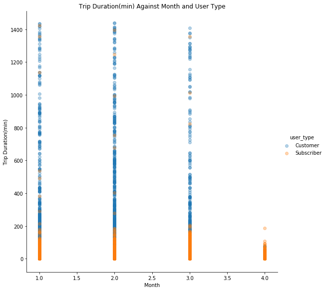

```python
g = sns.FacetGrid(data =df_clean, hue = 'user_type', height = 8)
g.map(plt.scatter, 'st_month','duration_min', alpha = 1/3)
g.add_legend()
plt.title('Trip Duration(min) Against Month and User Type')
plt.xlabel('Month')
plt.ylabel('Trip Duration(min)');
```

Above scatter plot shows the Trip duration minutes of each month and user_type

## user_type vs weekday

```python
# Prepare df for subscriber
subscriber_df = df_clean.query('user_type == "Subscriber"').groupby(['st_hour','st_weekday']).agg({'bike_id' : 'count'})
subscriber_df = subscriber_df.pivot_table(index='st_hour', columns='st_weekday', values='bike_id')
# Prepare df for customer
customer_df = df_clean.query('user_type == "Customer"').groupby(['st_hour','st_weekday']).agg({'bike_id' : 'count'})
customer_df = customer_df.pivot_table(index='st_hour', columns='st_weekday', values='bike_id')
```

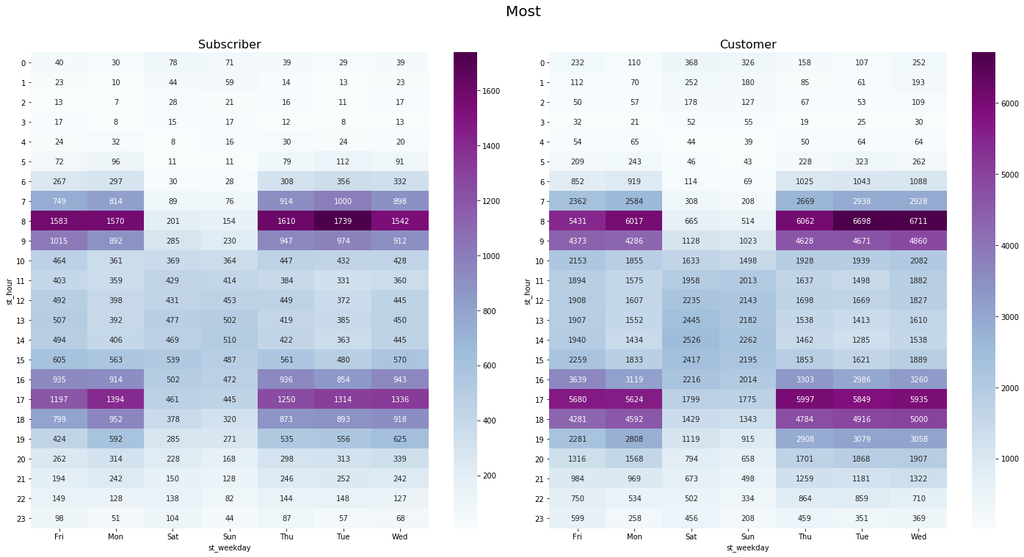

```python
#plotting heatmap
plt.subplots(figsize=(20,10))
fig1 = plt.subplot(1,2,1)
ax1 = sns.heatmap(subscriber_df, annot=True, fmt='d', cmap='BuPu')
plt.title('Subscriber',size=16)
plt.yticks(rotation=360)
fig2 = plt.subplot(1,2,2)
ax2 = sns.heatmap(customer_df, annot=True, fmt='d', cmap='BuPu')
plt.title('Customer',size=16)
plt.yticks(rotation=360)
plt.suptitle("Most ", size=20, y=1.05)
plt.tight_layout();
```

### Were there any interesting or surprising interactions between features?

The interactions between features are all supplementing each other and quite make sense when looked at combined. However the service seems to close in april month.